# Telco User Churn Classification

İlker Zeybek

January 29, 2021

# Introduction

Predicting the customer behaviour is important for retaining them in the service for maximizing the profit of the businesses. Therefore, we can gain important insights from a certain characteristics of a customers that churned or retained. This homework is about tuning the hyperparameters of classification algorithms, namely Random Forest Classifier and Stochastic Gradient Boosting Classifier.

# Dataset Info

In this dataset, each row represents a customer, each column contains customer’s attributes described. The raw data contains 7043 rows (customers) and 21 columns (features). The “Churn” column is our target. The data set includes information about:

- Customer ID: Customer ID
- Gender: Whether the customer is a male or a female
- SeniorCitizen: Whether the customer is a senior citizen or not (1, 0)
- Partner: Whether the customer has a partner or not (Yes, No)
- Dependents: Whether the customer has dependents or not (Yes, No)
- Tenure: Number of months the customer has stayed with the company
- PhoneService: Whether the customer has a phone service or not (Yes, No)
- MultipleLines: Whether the customer has multiple lines or not (Yes, No, No phone service)
- InternetService: Customer’s internet service provider (DSL, Fiber optic, No)
- OnlineSecurity: Whether the customer has online security or not (Yes, No, No internet service)
- OnlineBackup: Whether the customer has online backup or not (Yes, No, No internet service)
- DeviceProtection: Whether the customer has device protection or not (Yes, No, No internet service)
- TechSupport: Whether the customer has tech support or not (Yes, No, No internet service)
- StreamingTV: Whether the customer has streaming TV or not (Yes, No, No internet service)
- StreamingMovies: Whether the customer has streaming movies or not (Yes, No, No internet service)
- Contract: The contract term of the customer (Month-to-month, One year, Two year)
- PaperlessBilling: Whether the customer has paperless billing or not (Yes, No)
- PaymentMethod: The customer’s payment method (Electronic check, Mailed check, Bank transfer (automatic), Credit card (automatic))
- MonthlyCharges: The amount charged to the customer monthly
- TotalCharges: The total amount charged to the customer
- Churn: Whether the customer churned or not (Yes or No)

# Data Manipulation and Preparation

Firstly, I have loaded the necessary packages for future needs.

```r
#Loading the necessary packages
library(randomForest)
library(caret)
library(e1071)
library(ranger)
library(MLmetrics)
```

Then, I have loaded the data into R and set the seed for reproducibility.

```r
#Reading the data and setting the seed
data <- read.csv("churn.csv", stringsAsFactors = T)
set.seed(582)
```

As a first look, I have checked whether there is a missing data. After finding few missing values, I have omitted them, because there is not much missing data that will effect the results.

```r
#Removing NAs from the dataset
str(data)
```

```
## 'data.frame':    7043 obs. of  21 variables:
##  $ customerID      : Factor w/ 7043 levels "0002-ORFBO","0003-MKNFE",..: 5376 3963 2565 5536 6512 6552 1003 4771 5605 4535 ...
##  $ gender          : Factor w/ 2 levels "Female","Male": 1 2 2 2 1 1 2 1 1 2 ...
##  $ SeniorCitizen   : int  0 0 0 0 0 0 0 0 0 0 ...
##  $ Partner         : Factor w/ 2 levels "No","Yes": 2 1 1 1 1 1 1 1 2 1 ...
##  $ Dependents      : Factor w/ 2 levels "No","Yes": 1 1 1 1 1 1 2 1 1 2 ...
##  $ tenure          : int  1 34 2 45 2 8 22 10 28 62 ...
##  $ PhoneService    : Factor w/ 2 levels "No","Yes": 1 2 2 1 2 2 2 1 2 2 ...
##  $ MultipleLines   : Factor w/ 3 levels "No","No phone service",..: 2 1 1 2 1 3 3 2 3 1 ...
##  $ InternetService : Factor w/ 3 levels "DSL","Fiber optic",..: 1 1 1 1 2 2 2 1 2 1 ...
##  $ OnlineSecurity  : Factor w/ 3 levels "No","No internet service",..: 1 3 3 3 1 1 1 3 1 3 ...
##  $ OnlineBackup    : Factor w/ 3 levels "No","No internet service",..: 3 1 3 1 1 1 3 1 1 3 ...
##  $ DeviceProtection: Factor w/ 3 levels "No","No internet service",..: 1 3 1 3 1 3 1 1 3 1 ...
##  $ TechSupport     : Factor w/ 3 levels "No","No internet service",..: 1 1 1 3 1 1 1 1 3 1 ...
##  $ StreamingTV     : Factor w/ 3 levels "No","No internet service",..: 1 1 1 1 1 3 3 1 3 1 ...
##  $ StreamingMovies : Factor w/ 3 levels "No","No internet service",..: 1 1 1 1 1 3 1 1 3 1 ...
##  $ Contract        : Factor w/ 3 levels "Month-to-month",..: 1 2 1 2 1 1 1 1 1 2 ...
##  $ PaperlessBilling: Factor w/ 2 levels "No","Yes": 2 1 2 1 2 2 2 1 2 1 ...
##  $ PaymentMethod   : Factor w/ 4 levels "Bank transfer (automatic)",..: 3 4 4 1 3 3 2 4 3 1 ...
##  $ MonthlyCharges  : num  29.9 57 53.9 42.3 70.7 ...
##  $ TotalCharges    : num  29.9 1889.5 108.2 1840.8 151.7 ...
##  $ Churn           : Factor w/ 2 levels "No","Yes": 1 1 2 1 2 2 1 1 2 1 ...
```

```r
sapply(data, function(x) sum(is.na(x)))
```

```
##       customerID           gender    SeniorCitizen          Partner       Dependents           tenure     PhoneService    MultipleLines
##                0                0                0                0                0                0                0                0
##  InternetService   OnlineSecurity     OnlineBackup DeviceProtection      TechSupport      StreamingTV  StreamingMovies         Contract
##                0                0                0                0                0                0                0                0
## PaperlessBilling    PaymentMethod   MonthlyCharges     TotalCharges            Churn
##                0                0                0               11                0
```

```r
data <- na.omit(data)
```

After that, I have normalized the numerical columns, which are MonthlyCharges and TotalCharges, in order to handle highly varying values in these columns.

```r
data[, 19:20] <- scale(data[, 19:20])
```

After normalizing the numerical columns, I have created a factors out of the Tenure feature. Classified the customers as their membership years. Then, handled all of the categorical variables in the data set by renaming their levels. Lastly, I have removed the customer ID column, which is pretty obvious that it is a non-predictive feature.

```r
for(i in 1:nrow(data)){
  if(data[i, "tenure"] >= 0 & data[i, "tenure"] <= 12){
    data$tenure[i] <- "0-1 years"
  }else if(data[i, "tenure"] > 12 & data[i, "tenure"] <= 24){
    data$tenure[i] <- "1-2 years"
  }else if(data[i, "tenure"] > 24 & data[i, "tenure"] <= 36){
    data$tenure[i] <- "2-3 years"
  }else if(data[i, "tenure"] > 36 & data[i, "tenure"] <= 48){
    data$tenure[i] <- "3-4 years"
  }else if(data[i, "tenure"] > 48 & data[i, "tenure"] <= 60){
    data$tenure[i] <- "4-5 years"
  }else{
    data$tenure[i] <- "More than 5 years"
  }
}
data$tenure <- factor(data$tenure)
#Converting SeniorCitizen as a factor
data$SeniorCitizen <- as.factor(ifelse(data$SeniorCitizen == 1, "Yes", "No"))
#Converting "No", "No internet service" and "Yes" into categorical variables with 2 levels
levels(data$MultipleLines) <- c("No","No","Yes")
levels(data$OnlineSecurity) <- c("No","No","Yes")
levels(data$OnlineBackup) <- c("No","No","Yes")
levels(data$DeviceProtection) <- c("No","No","Yes")
levels(data$TechSupport) <- c("No","No","Yes")
levels(data$StreamingTV) <- c("No","No","Yes")
levels(data$StreamingMovies) <- c("No","No","Yes")
#Removing the ID column
data <- data[,2:21]
```

# Model Building

In order to build classification models, I have to divide data set into train and test sets. By randomly sampling 70% of the row indices, I have created the training set. The remaining rows forming the test set.

```r
#Split test-train
train_indices <- sample(1:7032, 7032*0.7)
train <- data[train_indices,]
test <- data[-train_indices,]
```

Since the output classes are imbalanced, I have to set a baseline accuracy. This baseline accuracy is the accuracy that if I label every outcome as “No” churn.

```r
#Baseline accuracy if we say "No churn" to every customer.
sum(data$Churn == "No") / nrow(data)
```

```
## [1] 0.734215
```

## Random Forest Classifier

After splitting the data, I have started modeling with the Random Forest classifier. We have to tune the “mtry” hyperparameter in this model according to our homework assignment. Firstly, I have created the 10-folds for cross-validation with 1 repeat. Then I have conducted a grid search for best mtry parameter while keeping minimum node size at 5, number of trees at 500 while using gini index. I have searched the best setting in 2, 5, 7, 9, 11, 13 mtry values. According to the results of the grid search:

- Optimal mtry = 2.

This means Random Forest Algorithm will use 2 randomly sampled features as candidates at each split.

```r
folds <- createMultiFolds(train$Churn, k = 10, times = 1)
control <- trainControl(method = "cv", number = 10, verboseIter = TRUE, summaryFunction = twoClassSummary,
                        classProbs = TRUE, savePredictions = TRUE, index = folds, allowParallel = TRUE)
tune_grid <- expand.grid(mtry = c(2, 5, 7, 9, 11, 13), splitrule = "gini", min.node.size = 5)
rf_gridsearch <- train(Churn ~., data = train, method = "ranger", metric = "Accuracy",
                       tuneGrid = tune_grid, trControl = control, num.trees = 500)
```

```r
rf_gridsearch
```

```
## Random Forest
##
## 4922 samples
##   19 predictor
##    2 classes: 'No', 'Yes'
##
## No pre-processing
## Resampling: Cross-Validated (10 fold)
## Summary of sample sizes: 4430, 4430, 4430, 4429, 4430, 4430, ...
## Resampling results across tuning parameters:
##
##   mtry  ROC        Sens       Spec
##    2    0.8412346  0.9337207  0.4104580
##    5    0.8348522  0.9074829  0.4896301
##    7    0.8329305  0.9041703  0.5011509
##    9    0.8305176  0.9033431  0.4965355
##   11    0.8285906  0.9025136  0.5011803
##   13    0.8266934  0.9030676  0.4965590
##
## Tuning parameter 'splitrule' was held constant at a value of gini
## Tuning parameter 'min.node.size' was held constant at a value of 5
## ROC was used to select the optimal model using the largest value.
## The final values used for the model were mtry = 2, splitrule = gini and min.node.size = 5.
```

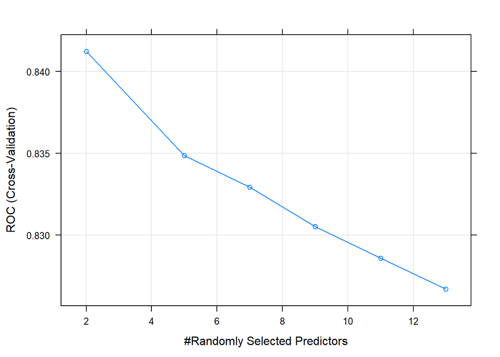

```r
plot(rf_gridsearch)
```

```r
predictions <- predict(rf_gridsearch, newdata = test)
Accuracy(predictions, test$Churn)
```

```
## [1] 0.843128
```

```r
ConfusionMatrix(predictions, test$Churn)
```

```
##       y_pred
## y_true   No  Yes
##    No  1464   70
##    Yes  261  315
```

```r
predictions <- predict(rf_gridsearch, newdata = train)
Accuracy(predictions, train$Churn)
```

```
## [1] 0.8370581
```

## Stochastic Gradient Boosting Classifier

In the GBM model, we have to tune our depth, learning rate, and number of trees hyper paramteter according to our homework assignment. Since my computer is not good at computing the grid search results for many parameter values, I have used less parameter levels for this classification algorithm. According to the grid search for best hyperparameters:

- Optimal Number of trees = 1000.
- Optimal Depth = 3.
- Optimal Learning Rate = 0.01.

Increasing the number of trees reduces the error on training set, but setting it too high may lead to over-fitting. Depth is the number of splits GBM has to perform on a tree (starting from a single node). In the context of GBMs, shrinkage is used for reducing, or shrinking, the impact of each additional fitted base-learner (tree). It reduces the size of incremental steps and thus penalizes the importance of each consecutive iteration.

```r
folds <- createMultiFolds(train$Churn, k = 10, times = 1)
control <- trainControl(method = "cv", number = 10, verboseIter = TRUE, summaryFunction = twoClassSummary,
                        classProbs = TRUE, savePredictions = TRUE, index = folds, allowParallel = TRUE)
tune_grid <- expand.grid(interaction.depth=c(1, 3, 5), n.trees = c(500, 1000), shrinkage=c(0.01, 0.001), n.minobsinnode = 10)
gbm_gridsearch <- train(Churn ~., data = train, method = "gbm", metric = "Accuracy", tuneGrid = tune_grid, trControl = control)
```

```r
gbm_gridsearch
```

```
## Stochastic Gradient Boosting
##
## 4922 samples
##   19 predictor
##    2 classes: 'No', 'Yes'
##
## No pre-processing
## Resampling: Cross-Validated (10 fold)
## Summary of sample sizes: 4430, 4430, 4430, 4430, 4429, 4430, ...
## Resampling results across tuning parameters:
##
##   shrinkage  interaction.depth  n.trees  ROC        Sens       Spec
##   0.001      1                   500     0.7920653  1.0000000  0.0000000
##   0.001      1                  1000     0.8063922  1.0000000  0.0000000
##   0.001      3                   500     0.8307619  1.0000000  0.0000000
##   0.001      3                  1000     0.8348933  0.9809438  0.1567998
##   0.001      5                   500     0.8371739  1.0000000  0.0000000
##   0.001      5                  1000     0.8407244  0.9715523  0.2367645
##   0.010      1                   500     0.8413019  0.9629918  0.2736641
##   0.010      1                  1000     0.8474748  0.9298540  0.4266530
##   0.010      3                   500     0.8490578  0.9171491  0.4781268
##   0.010      3                  1000     0.8499763  0.9077561  0.5104110
##   0.010      5                   500     0.8494544  0.9094151  0.4904287
##   0.010      5                  1000     0.8487531  0.9041657  0.5111627
##
## Tuning parameter 'n.minobsinnode' was held constant at a value of 10
## ROC was used to select the optimal model using the largest value.
## The final values used for the model were n.trees = 1000, interaction.depth = 3, shrinkage = 0.01 and n.minobsinnode = 10.
```

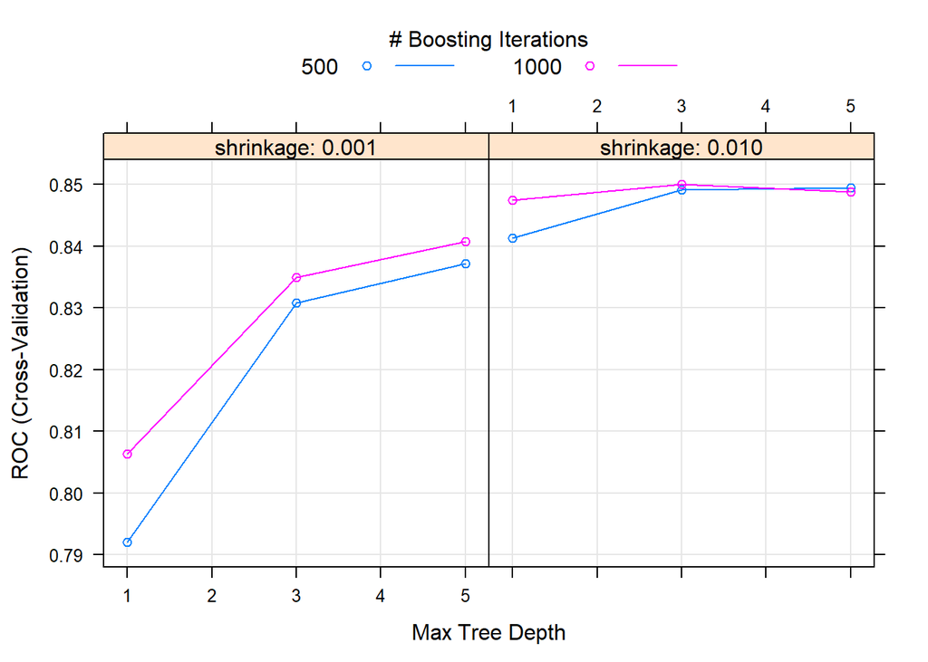

```r
plot(gbm_gridsearch)
```

```r
predictions <- predict(gbm_gridsearch, newdata = test)
Accuracy(predictions, test$Churn)
```

```
## [1] 0.8085308
```

```r
ConfusionMatrix(predictions, test$Churn)
```

```
##       y_pred
## y_true   No  Yes
##    No  1398  136
##    Yes  268  308
```

```r
predictions <- predict(gbm_gridsearch, newdata = train)
Accuracy(predictions, train$Churn)
```

```
## [1] 0.8138968
```

## Weighted Random Forest Classifier

Since we have imbalanced dataset, I have introduced the weights of the classes into the algorithm. According to the grid search for besthyper parameters:

- Optimal mtry = 2.

This means Random Forest Algorithm will use 2 randomly sampled features as candidates at each split.

```r
model_weights <- ifelse(train$Churn == "No",
                        sum(train$Churn == "No")/nrow(train),
                        sum(train$Churn == "Yes")/nrow(train))
folds <- createMultiFolds(train$Churn, k = 10, times = 1)
control <- trainControl(method = "cv", number = 10, verboseIter = TRUE, summaryFunction = twoClassSummary,
                        classProbs = TRUE, savePredictions = TRUE, index = folds, allowParallel = TRUE)
tune_grid <- expand.grid(mtry = c(2, 5, 7, 9, 11, 13), splitrule = "gini", min.node.size = 5)
weighted_rf_gridsearch <- train(Churn ~., data = train, method = "ranger", weights = model_weights,
                       metric = "Accuracy", tuneGrid = tune_grid, trControl = control, num.trees = 500)
```

```r
weighted_rf_gridsearch
```

```
## Random Forest
##
## 4922 samples
##   19 predictor
##    2 classes: 'No', 'Yes'
##
## No pre-processing
## Resampling: Cross-Validated (10 fold)
## Summary of sample sizes: 4430, 4430, 4430, 4430, 4429, 4430, ...
## Resampling results across tuning parameters:
##
##   mtry  ROC        Sens       Spec
##    2    0.8401752  0.9964096  0.06074574
##    5    0.8340759  0.9743185  0.24373459
##    7    0.8327684  0.9699002  0.26753376
##    9    0.8315796  0.9682419  0.27984146
##   11    0.8290967  0.9663090  0.28675279
##   13    0.8277924  0.9640991  0.29674105
##
## Tuning parameter 'splitrule' was held constant at a value of gini
## Tuning parameter 'min.node.size' was held constant at a value of 5
## ROC was used to select the optimal model using the largest value.
## The final values used for the model were mtry = 2, splitrule = gini and min.node.size = 5.
```

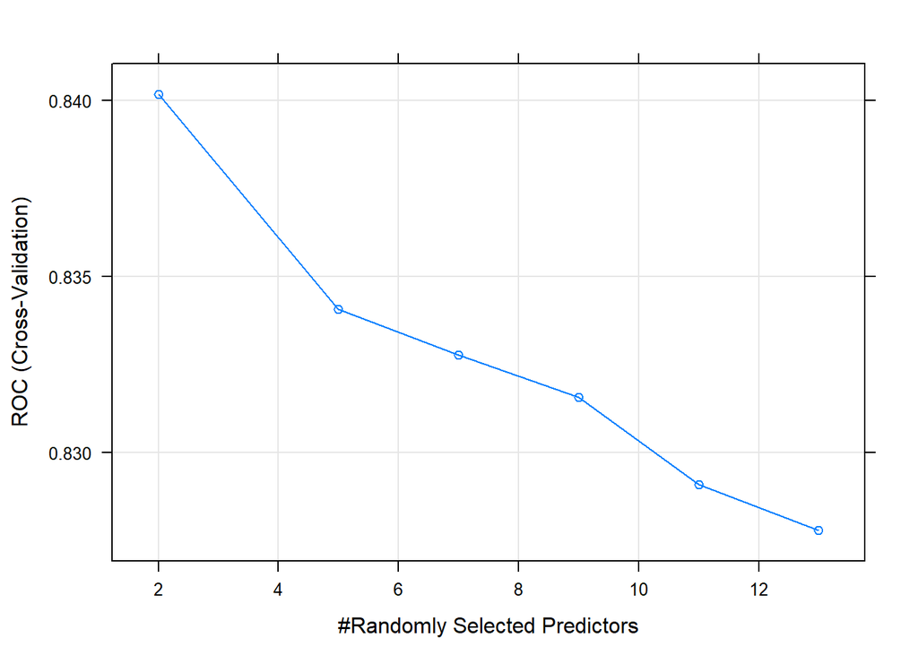

```r
plot(weighted_rf_gridsearch)
```

```r
predictions <- predict(weighted_rf_gridsearch, newdata = test)
Accuracy(predictions, test$Churn)
```

```
## [1] 0.7488152
```

```r
ConfusionMatrix(predictions, test$Churn)
```

```
##       y_pred
## y_true   No  Yes
##    No  1531    3
##    Yes  527   49
```

```r
predictions <- predict(weighted_rf_gridsearch, newdata = train)
Accuracy(predictions, train$Churn)
```

```
## [1] 0.7523364
```

## Weighted Stochastic Gradient Boosting Classifier

In the GBM model, we have to tune our depth, learning rate, and number of trees hyper paramteter according to our homework assignment. Since my computer is not good at computing the grid search results for many parameter values, I have used less parameter levels for this classification algorithm. According to the grid search for best hyperparameters:

- Optimal Number of trees = 1000.
- Optimal Depth = 3.
- Optimal Learning Rate = 0.01.

Increasing the number of trees reduces the error on training set, but setting it too high may lead to over-fitting. Depth is the number of splits GBM has to perform on a tree (starting from a single node). In the context of GBMs, shrinkage is used for reducing, or shrinking, the impact of each additional fitted base-learner (tree). It reduces the size of incremental steps and thus penalizes the importance of each consecutive iteration.

```r
folds <- createMultiFolds(train$Churn, k = 10, times = 1)
control <- trainControl(method = "cv", number = 10, verboseIter = TRUE, summaryFunction = twoClassSummary,
                        classProbs = TRUE, savePredictions = TRUE, index = folds, allowParallel = TRUE)
tune_grid <- expand.grid(interaction.depth=c(1, 3, 5), n.trees = c(500, 1000), shrinkage=c(0.01, 0.001), n.minobsinnode = 10)
weighted_gbm_gridsearch <- train(Churn ~., data = train, method = "gbm", weights = model_weights,
                        metric = "Accuracy", tuneGrid = tune_grid, trControl = control)
```

```r
weighted_gbm_gridsearch
```

```
## Stochastic Gradient Boosting
##
## 4922 samples
##   19 predictor
##    2 classes: 'No', 'Yes'
##
## No pre-processing
## Resampling: Cross-Validated (10 fold)
## Summary of sample sizes: 4430, 4429, 4430, 4430, 4430, 4430, ...
## Resampling results across tuning parameters:
##
##   shrinkage  interaction.depth  n.trees  ROC        Sens       Spec
##   0.001      1                   500     0.7856408  1.0000000  0.00000000
##   0.001      1                  1000     0.8030461  1.0000000  0.00000000
##   0.001      3                   500     0.8254536  1.0000000  0.00000000
##   0.001      3                  1000     0.8354215  1.0000000  0.00000000
##   0.001      5                   500     0.8308585  1.0000000  0.00000000
##   0.001      5                  1000     0.8382558  0.9972383  0.03227833
##   0.010      1                   500     0.8371487  0.9958571  0.08071051
##   0.010      1                  1000     0.8455791  0.9928200  0.12219612
##   0.010      3                   500     0.8475167  0.9870204  0.18829712
##   0.010      3                  1000     0.8489764  0.9801151  0.22519671
##   0.010      5                   500     0.8484694  0.9803913  0.22673517
##   0.010      5                  1000     0.8479683  0.9732105  0.25748092
##
## Tuning parameter 'n.minobsinnode' was held constant at a value of 10
## ROC was used to select the optimal model using the largest value.
## The final values used for the model were n.trees = 1000, interaction.depth = 3, shrinkage = 0.01 and n.minobsinnode = 10.
```

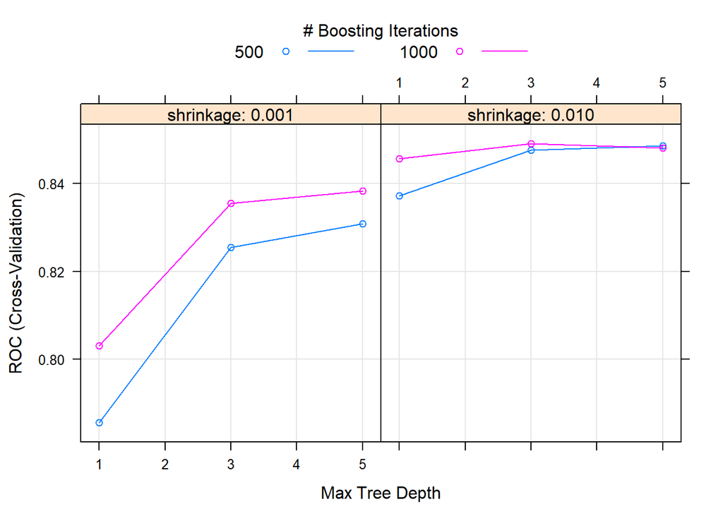

```r
plot(weighted_gbm_gridsearch)
```

```r
predictions <- predict(weighted_gbm_gridsearch, newdata = test)
Accuracy(predictions, test$Churn)
```

```
## [1] 0.7824645
```

```r
ConfusionMatrix(predictions, test$Churn)
```

```
##       y_pred
## y_true   No  Yes
##    No  1500   34
##    Yes  425  151
```

```r
predictions <- predict(weighted_gbm_gridsearch, newdata = train)
Accuracy(predictions, train$Churn)
```

```
## [1] 0.7868753
```